# Regression Project

Brandon Harden, Julie Fisher, Karelys Osuana, Mingjian Shi

April 23, 2017

# Examination of the data

## Initial review

Our first step was to get a feel for the data. We looked at the dimensions and variable names. With only 100 rows we could have looked at the whole data set using View(), but instead looked at just the first 5 as this is an initial glance and is a good practice with larger data sets. Looking at the first 5 values revealed that the W2MiDT variable is a factor. Before moving on, we made this conversion to continue our analysis.

```r
dim(comm_prop)
```

```
## [1] 100   7
```

```r
names(comm_prop)
```

```
## [1] "RentRate" "Age"      "OperExp"  "VacRate"  "SqFt"     "Taxes"
## [7] "W2MiDT"
```

## Size and shape of data

In handling the factor, we made the 0 the ‘No’ value and 1 the ‘Yes’ value. Next we determined whether or not there were any missing values. As there are no missing values we don’t need to worry about those effecting our results. Knowing there were no missing values, we ran the summary() function to get an idea for the size and shape of the data.

```r
comm_prop$W2MiDT <- factor(comm_prop$W2MiDT, labels = c("No", "Yes"))
head(comm_prop)
```

```
## # A tibble: 6 × 7
##   RentRate   Age OperExp VacRate   SqFt Taxes W2MiDT
##      <dbl> <int>   <dbl>   <dbl>  <int> <dbl> <fctr>
## 1     13.5     1    5.02    0.14 123000  2.21     No
## 2     12.0    14    8.19    0.27 104079  1.87     No
## 3     10.5    16    3.00    0.00  39998  0.72     No
## 4     15.0     4   10.70    0.05  57112  1.03     No
## 5     14.0    11    8.97    0.07  60000  1.08     No
## 6     10.5    15    9.45    0.24 101385  1.82     No
```

```r
ls.str(comm_prop)
```

```
## Age :  int [1:100] 1 14 16 4 11 15 2 1 1 8 ...
## OperExp :  num [1:100] 5.02 8.19 3 10.7 8.97 ...
## RentRate :  num [1:100] 13.5 12 10.5 15 14 10.5 14 16.5 17.5 16.5 ...
## SqFt :  int [1:100] 123000 104079 39998 57112 60000 101385 31300 248172 215000 251015 ...
## Taxes :  num [1:100] 2.21 1.87 0.72 1.03 1.08 1.82 0.56 4.47 3.87 4.52 ...
## VacRate :  num [1:100] 0.14 0.27 0 0.05 0.07 0.24 0.19 0.6 0 0.03 ...
## W2MiDT :  Factor w/ 2 levels "No","Yes": 1 1 1 1 1 1 1 2 2 2 ...
```

```r
sum(is.na(comm_prop))
```

```
## [1] 0
```

```r
summary(comm_prop)
```

```
##     RentRate          Age           OperExp          VacRate
##  Min.   :10.50   Min.   : 0.00   Min.   : 3.000   Min.   :0.0000
##  1st Qu.:14.00   1st Qu.: 2.00   1st Qu.: 7.997   1st Qu.:0.0000
##  Median :15.00   Median : 4.00   Median :10.370   Median :0.0400
##  Mean   :15.13   Mean   : 8.01   Mean   : 9.658   Mean   :0.0801
##  3rd Qu.:16.50   3rd Qu.:15.00   3rd Qu.:11.660   3rd Qu.:0.0925
##  Max.   :19.25   Max.   :20.00   Max.   :14.620   Max.   :0.7300
##       SqFt            Taxes       W2MiDT
##  Min.   : 27000   Min.   :0.490   No :64
##  1st Qu.: 73141   1st Qu.:1.315   Yes:36
##  Median :129614   Median :2.330
##  Mean   :166101   Mean   :2.990
##  3rd Qu.:244547   3rd Qu.:4.402
##  Max.   :484290   Max.   :8.720
```

# Visual representation to understand distrubutions

Next we visualized the data to determine if it is normally distributed.These visualizations reveled that not all variables are normally distributed. Age is bi-modal; OperExp is left skewed; and VacRate, SqFt, and Taxes are all right skewed. The fact that not all of the variables are normally distributed doesn’t invalidate the results of the rest of the analysis, but will impact the overall effectiveness of detecting true differences.

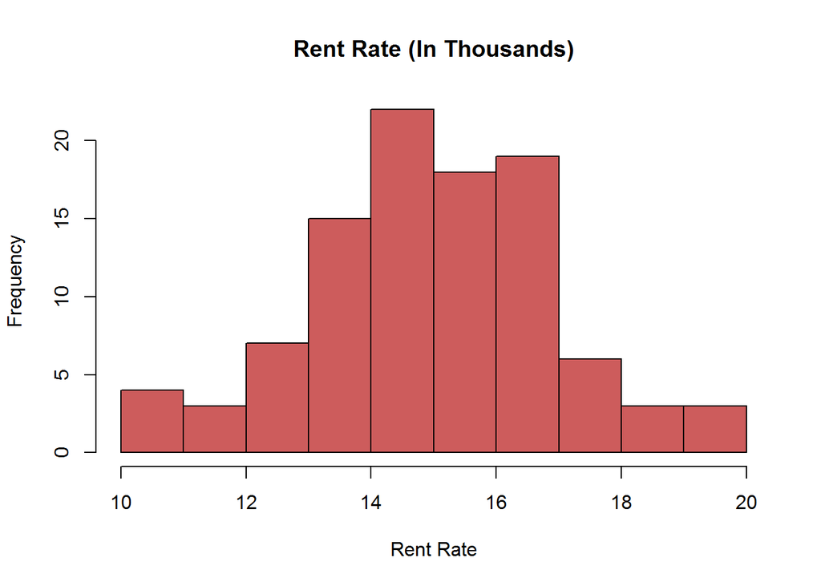

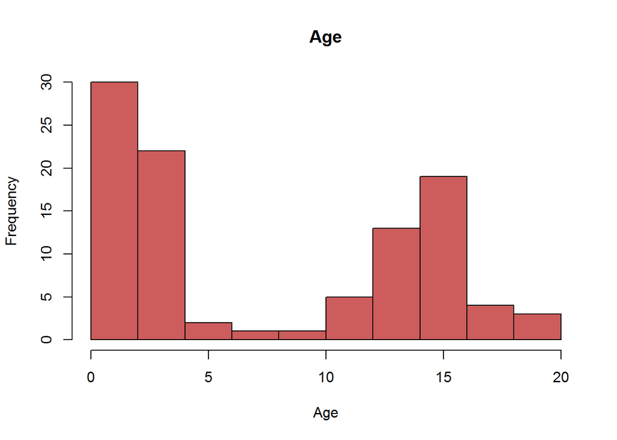

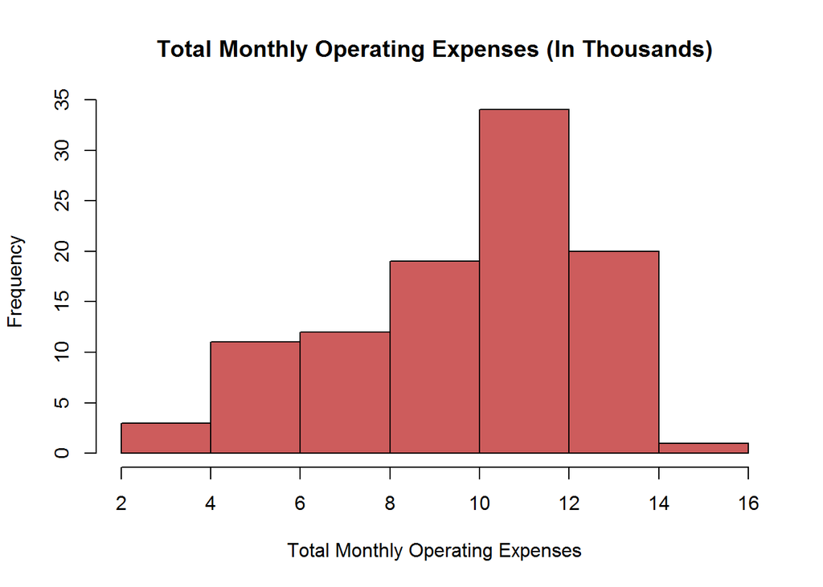

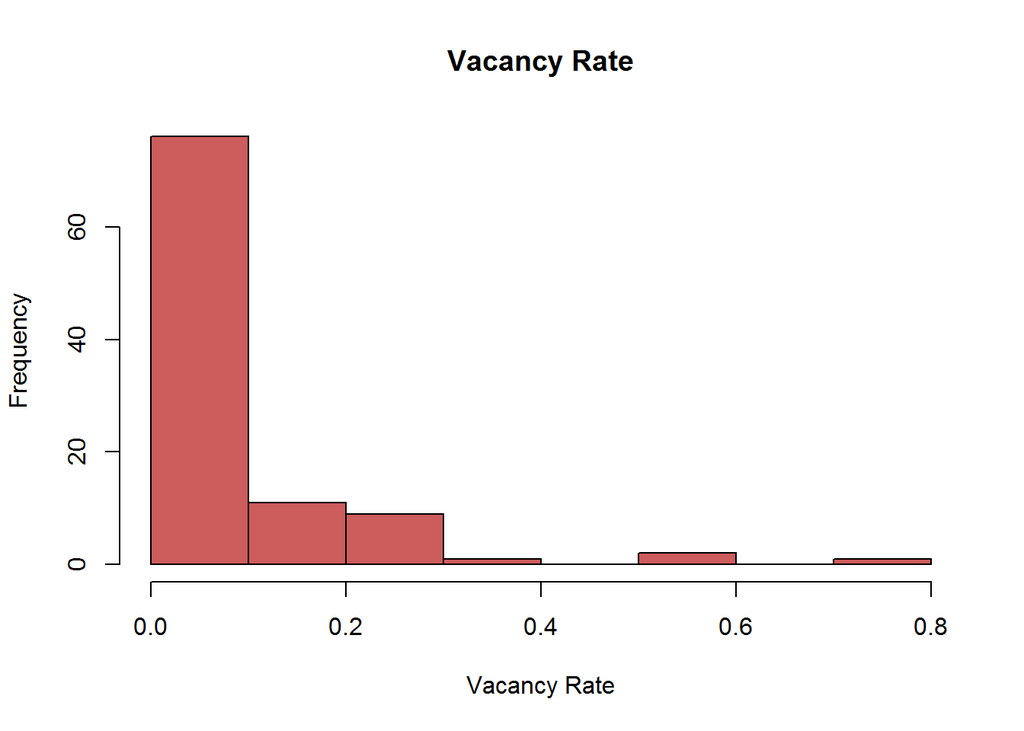

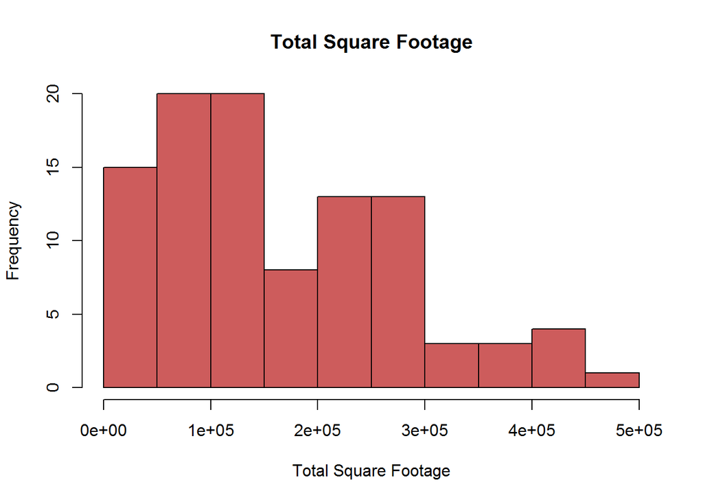

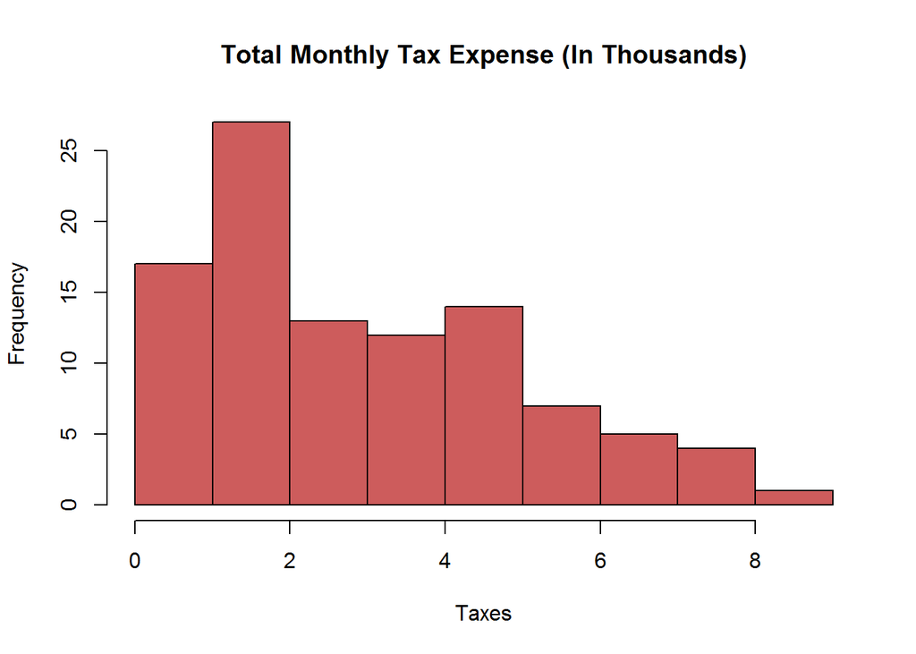

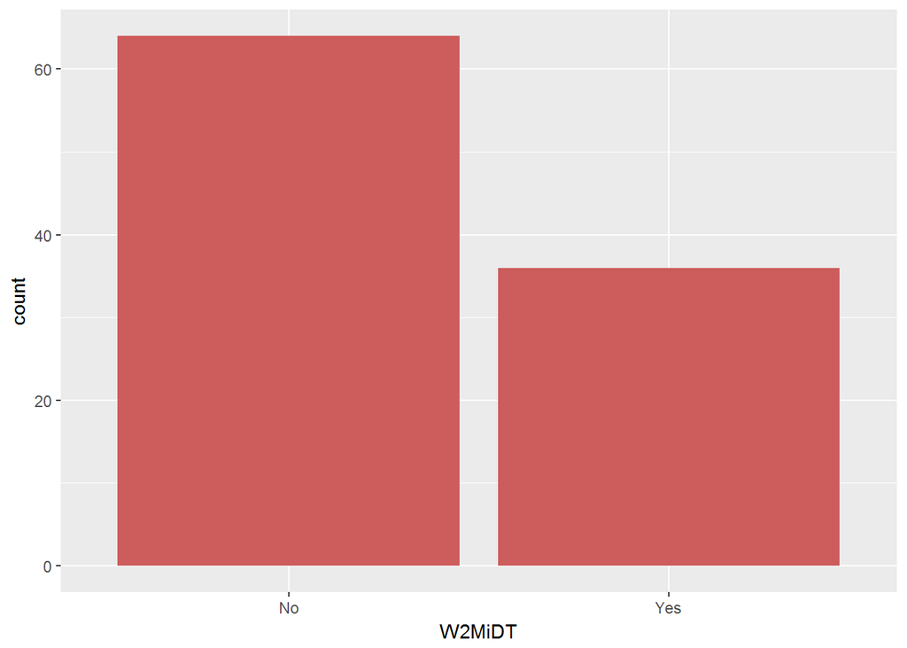

# Examine correlations

Next we needed to see how the variables related to each other. To do this we used the pairs() and corrplot() functions to visualize all the interactions and cor() to get numerical representations of these relations. We noticed that cor() only accepts numeric variables and so removed W2MiDT variable for just the functions requiring cor().

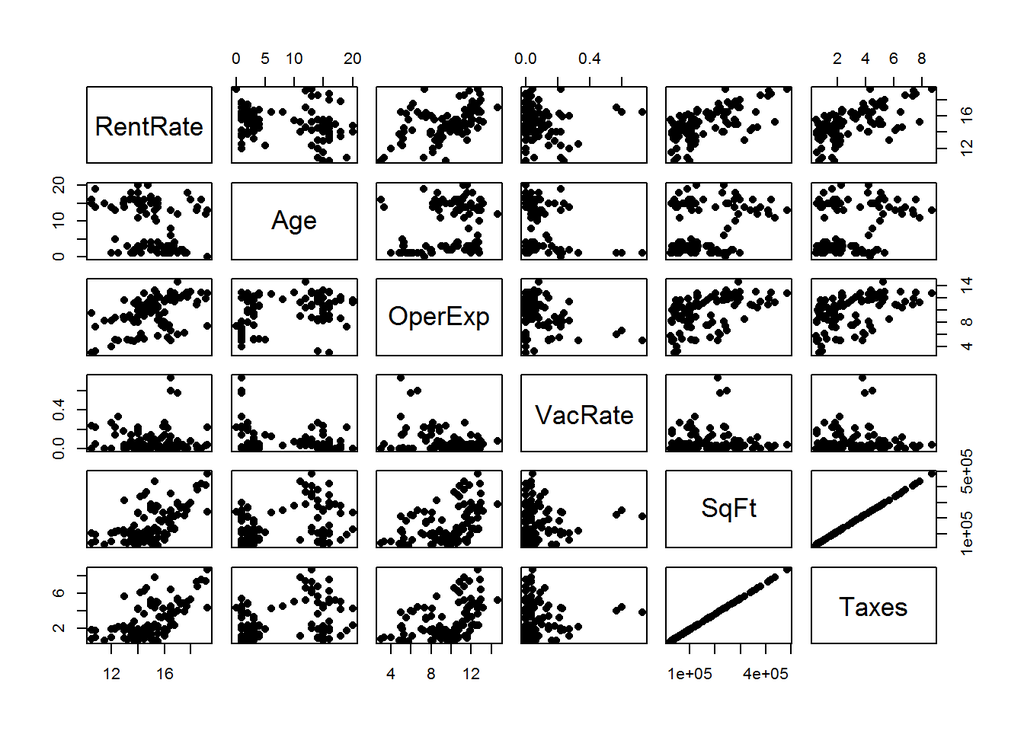

```r
pairs(comm_prop[,1:6], pch = 16)
```

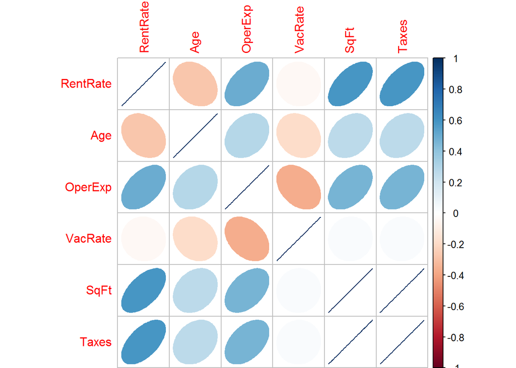

```r
numeric_df <- comm_prop[1:6]
corrplot(cor(numeric_df), method="ellipse")
```

```r
cor(numeric_df)
```

```
##             RentRate        Age    OperExp     VacRate       SqFt
## RentRate  1.00000000 -0.2717822  0.4961736 -0.03718869 0.58440930
## Age      -0.27178219  1.0000000  0.2807262 -0.18660828 0.26929259
## OperExp   0.49617362  0.2807262  1.0000000 -0.36605714 0.46658357
## VacRate  -0.03718869 -0.1866083 -0.3660571  1.00000000 0.02947991
## SqFt      0.58440930  0.2692926  0.4665836  0.02947991 1.00000000
## Taxes     0.58452951  0.2691128  0.4663997  0.02944071 0.99999918
##               Taxes
## RentRate 0.58452951
## Age      0.26911276
## OperExp  0.46639966
## VacRate  0.02944071
## SqFt     0.99999918
## Taxes    1.00000000
```

```r
df.full <- lm(RentRate ~ ., data = comm_prop)
summary(df.full)
```

```
##
## Call:
## lm(formula = RentRate ~ ., data = comm_prop)
##
## Residuals:
##      Min       1Q   Median       3Q      Max
## -2.65450 -0.59760 -0.02213  0.65394  2.57988
##
## Coefficients:
##               Estimate Std. Error t value Pr(>|t|)
## (Intercept) 12.2278960  0.4483644  27.272  < 2e-16 ***
## Age         -0.1040412  0.0185484  -5.609 2.08e-07 ***
## OperExp      0.2255069  0.0497984   4.528 1.76e-05 ***
## VacRate     -0.7568956  0.9114326  -0.830    0.408
## SqFt        -0.0005652  0.0007194  -0.786    0.434
## Taxes       31.7633824 39.9476685   0.795    0.429
## W2MiDTYes    1.4434308  0.2586992   5.580 2.36e-07 ***
## ---
## Signif. codes:  0 '***' 0.001 '**' 0.01 '*' 0.05 '.' 0.1 ' ' 1
##
## Residual standard error: 0.9884 on 93 degrees of freedom
## Multiple R-squared:  0.7463, Adjusted R-squared:   0.73
## F-statistic: 45.61 on 6 and 93 DF,  p-value: < 2.2e-16
```

# Choose outcome variable

The purpose of our analysis is to determine a price range to charge for renting out our building. This corresponds to the variable RentRate.

# Fit a model

## Multicollinearity

When we ran the pairs() and cor() functions we probably should have noticed the .999 correlation of the SqFt and Taxes variables, indicative of multicollinearity. However, it wasn’t until we started removing variables that we noticed the large effect on the efficacy of the model. As such, from the review of the initial results, it appeared that VacRate, SqFt, and Taxes were all minimally significant. We removed all three variables and reran the calculations to fit a first model.

In removing all three of these variables, the Adjusted R^2 value was reduced from 0.73 to 0.63. By adding values back in and rerunning the calculations, we discovered the multicollinearity. We chose to keep SqFt instead of Taxes. It appears that in this data, the majority of a calculation for determining taxes is based on square footage. Location, another variable accounted for in the data set, may also play a role in taxes, which would also cause discrepancy in our model.

```r
dfLessMin <- lm(RentRate ~ Age + OperExp + W2MiDT, data = comm_prop)
summary(dfLessMin)
```

```
##
## Call:
## lm(formula = RentRate ~ Age + OperExp + W2MiDT, data = comm_prop)
##
## Residuals:
##     Min      1Q  Median      3Q     Max
## -4.0112 -0.6539 -0.0132  0.6757  3.0006
##
## Coefficients:
##             Estimate Std. Error t value Pr(>|t|)
## (Intercept) 11.86213    0.44065  26.919  < 2e-16 ***
## Age         -0.06762    0.02030  -3.331  0.00123 **
## OperExp      0.31737    0.04897   6.481 3.91e-09 ***
## W2MiDTYes    2.06087    0.26985   7.637 1.65e-11 ***
## ---
## Signif. codes:  0 '***' 0.001 '**' 0.01 '*' 0.05 '.' 0.1 ' ' 1
##
## Residual standard error: 1.151 on 96 degrees of freedom
## Multiple R-squared:  0.6452, Adjusted R-squared:  0.6341
## F-statistic: 58.19 on 3 and 96 DF,  p-value: < 2.2e-16
```

## Adjusted model

Having accounted for the effect caused by the multicollinearity, we added SqFt back in and reran the calculations. These calculations show better results than those of all variables combined. The p-values of all included variables are significant and the F-statistic is significantly improved.

Initial Adjusted R^2: 0.73 Initial F-statistic: 45.61

New Adjusted R^2: 0.7313 New F-statistic: 68.35

```r
df_model <- lm(RentRate ~ Age + OperExp + W2MiDT + SqFt, data = comm_prop)
summary(df_model)
```

```
##
## Call:
## lm(formula = RentRate ~ Age + OperExp + W2MiDT + SqFt, data = comm_prop)
##
## Residuals:
##      Min       1Q   Median       3Q      Max
## -2.90483 -0.58081 -0.03454  0.57347  2.54837
##
## Coefficients:
##               Estimate Std. Error t value Pr(>|t|)
## (Intercept)  1.205e+01  3.789e-01  31.797  < 2e-16 ***
## Age         -1.040e-01  1.843e-02  -5.641 1.74e-07 ***
## OperExp      2.373e-01  4.406e-02   5.385 5.22e-07 ***
## W2MiDTYes    1.435e+00  2.539e-01   5.653 1.65e-07 ***
## SqFt         6.643e-06  1.112e-06   5.975 3.98e-08 ***
## ---
## Signif. codes:  0 '***' 0.001 '**' 0.01 '*' 0.05 '.' 0.1 ' ' 1
##
## Residual standard error: 0.986 on 95 degrees of freedom
## Multiple R-squared:  0.7421, Adjusted R-squared:  0.7313
## F-statistic: 68.35 on 4 and 95 DF,  p-value: < 2.2e-16
```

# Evaluate model

To determine the efficacy of our model, we re-ran calculations to review residuals, normality, variance, and determine if there was any other multicollinearity present in the data.

There was no discernible pattern to the residuals so there doesn’t appear to be any issues with normality or variance. There were two points outside the fitted model, that may warrant additional scrutiny to determine a best fit model.

The age variable continues to show a bi-modal distribution that appears to break buildings into under and over 10 year old categories. The associations between RentRate and OperExp and SqFt both make sense in that as OperExp and SqFt individually increase so too does the RentRate. All other results appear to be within an acceptable range.

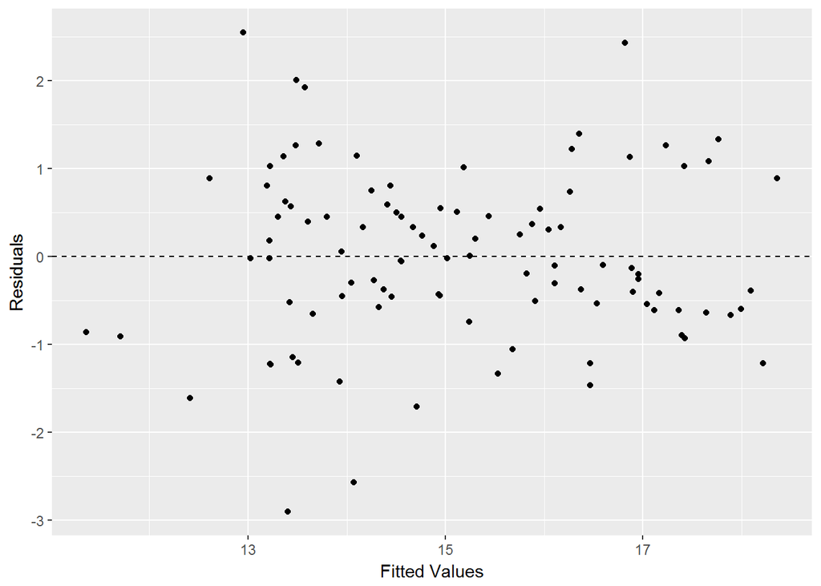

```r
full.df <- fortify(df_model)
ggplot(full.df, aes(x=.fitted, y=.resid)) +
  geom_point() +
  geom_hline(yintercept=0, linetype=2) +
  labs(x="Fitted Values", y="Residuals")
```

```r
shapiro.test(df_model$residuals)
```

```
##
##  Shapiro-Wilk normality test
##
## data:  df_model$residuals
## W = 0.98932, p-value = 0.6099
```

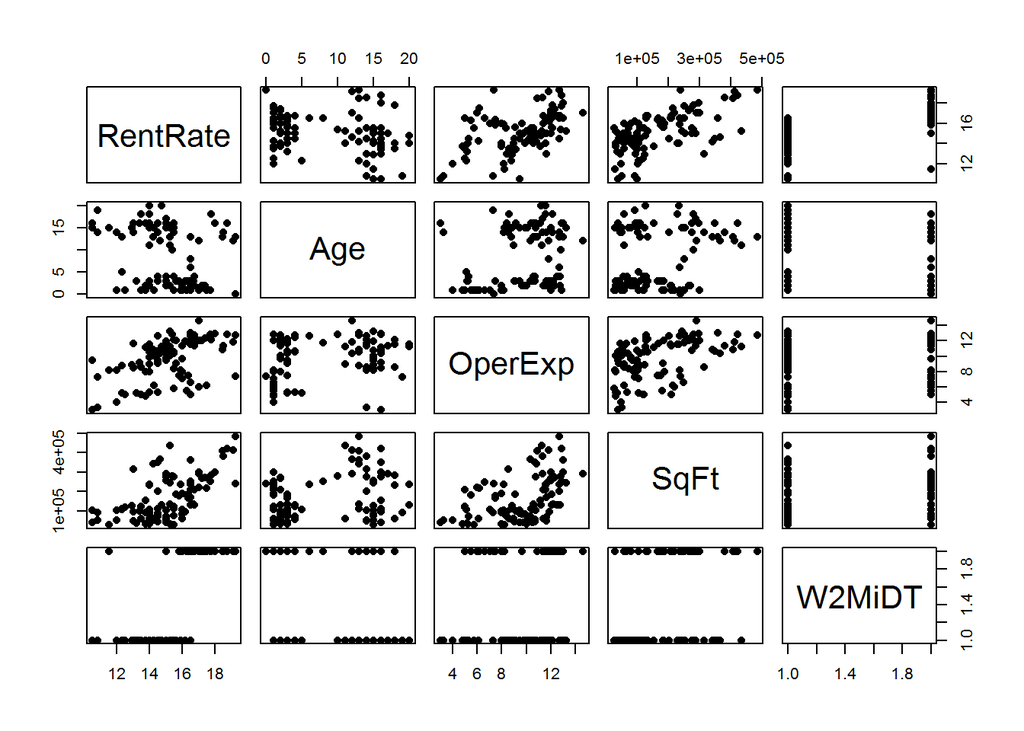

```r
pairs(comm_prop[-c(4,6)], pch=16)
```

```r
ncvTest(df_model)
```

```
## Non-constant Variance Score Test
## Variance formula: ~ fitted.values
## Chisquare = 3.279042    Df = 1     p = 0.07016989
```

```r
vif(df_model)
```

```
##      Age  OperExp   W2MiDT     SqFt
## 1.459694 1.366874 1.527237 1.582381
```

## Quality of fit

We created a plot to visualize how well the model using just single variables fits the data. As shown below, there are a lot of points that are further from our prediction that we would like.

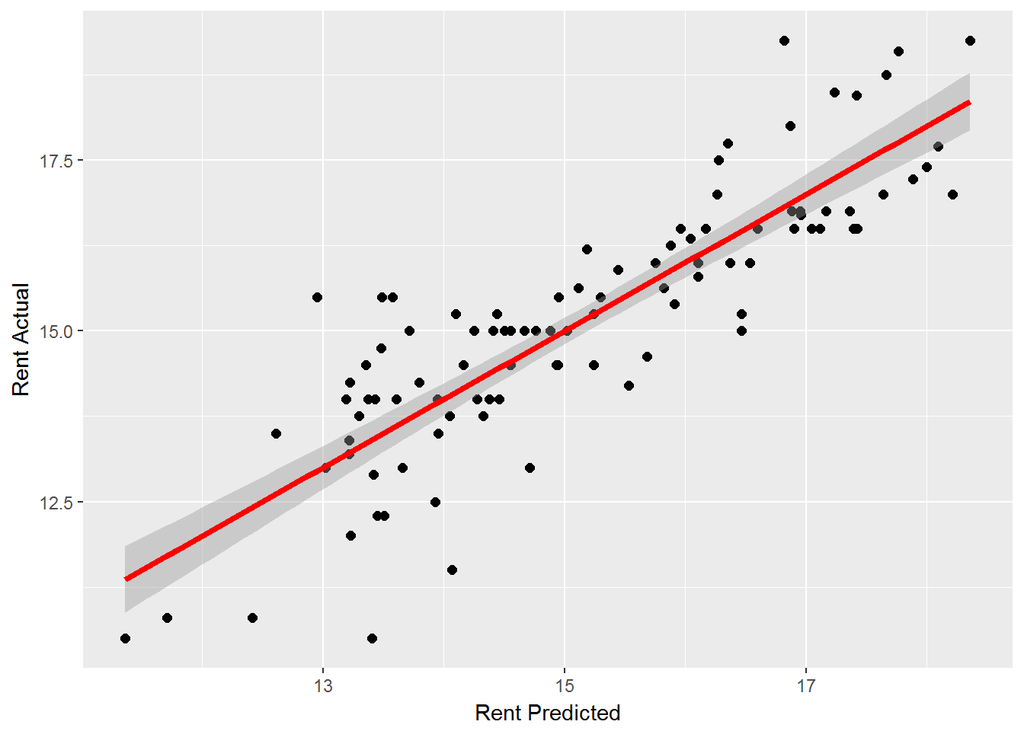

```r
ggplot(full.df, aes(x=.fitted, y=RentRate)) +
  geom_point(size=2) +
  geom_smooth(method="lm", color="red", lwd=1.5) +
  labs(x="Rent Predicted", y="Rent Actual")
```

## Extra Credit

In order to determine if there is a better fit model we need to account for how all the variables interact with each other as well. The first step is the create a model that reflects all variables and all variable interactions.

This doesn’t create a particularly precise model. While our Adjusted R^2 value has increased to 0.8428, our F-statistic has decreased to 36.38 and there are many variables that aren’t significant.

```r
model.full.int <- lm(RentRate ~ (Age + OperExp + VacRate + SqFt + W2MiDT)^2, data=comm_prop)
summary(model.full.int)
```

```
##
## Call:
## lm(formula = RentRate ~ (Age + OperExp + VacRate + SqFt + W2MiDT)^2,
##     data = comm_prop)
##
## Residuals:
##      Min       1Q   Median       3Q      Max
## -1.90664 -0.39851 -0.01688  0.39623  2.01293
##
## Coefficients:
##                     Estimate Std. Error t value Pr(>|t|)
## (Intercept)        1.249e+01  6.863e-01  18.202  < 2e-16 ***
## Age               -2.048e-01  5.912e-02  -3.464 0.000839 ***
## OperExp            2.895e-01  7.964e-02   3.635 0.000478 ***
## VacRate           -6.081e+00  3.420e+00  -1.778 0.078979 .
## SqFt               3.784e-06  6.164e-06   0.614 0.540867
## W2MiDTYes          1.451e+00  1.102e+00   1.317 0.191523
## Age:OperExp        1.156e-02  6.708e-03   1.723 0.088594 .
## Age:VacRate       -5.183e-01  1.931e-01  -2.684 0.008770 **
## Age:SqFt           2.560e-07  2.030e-07   1.261 0.210738
## Age:W2MiDTYes     -5.294e-02  4.376e-02  -1.210 0.229718
## OperExp:VacRate    6.061e-01  3.895e-01   1.556 0.123444
## OperExp:SqFt      -5.610e-07  5.037e-07  -1.114 0.268559
## OperExp:W2MiDTYes -1.759e-01  1.008e-01  -1.744 0.084737 .
## VacRate:SqFt       1.114e-05  1.362e-05   0.818 0.415760
## VacRate:W2MiDTYes -5.999e-02  2.557e+00  -0.023 0.981340
## SqFt:W2MiDTYes     1.162e-05  2.008e-06   5.789 1.19e-07 ***
## ---
## Signif. codes:  0 '***' 0.001 '**' 0.01 '*' 0.05 '.' 0.1 ' ' 1
##
## Residual standard error: 0.7542 on 84 degrees of freedom
## Multiple R-squared:  0.8666, Adjusted R-squared:  0.8428
## F-statistic: 36.38 on 15 and 84 DF,  p-value: < 2.2e-16
```

```r
model_all <- lm(RentRate ~ Age + OperExp + VacRate + SqFt + W2MiDT + Age:OperExp + Age:VacRate + Age:SqFt + Age:W2MiDT + OperExp:VacRate + OperExp:SqFt + OperExp:W2MiDT + VacRate:SqFt + VacRate:W2MiDT + SqFt:W2MiDT, data=comm_prop)
library(leaps)
```

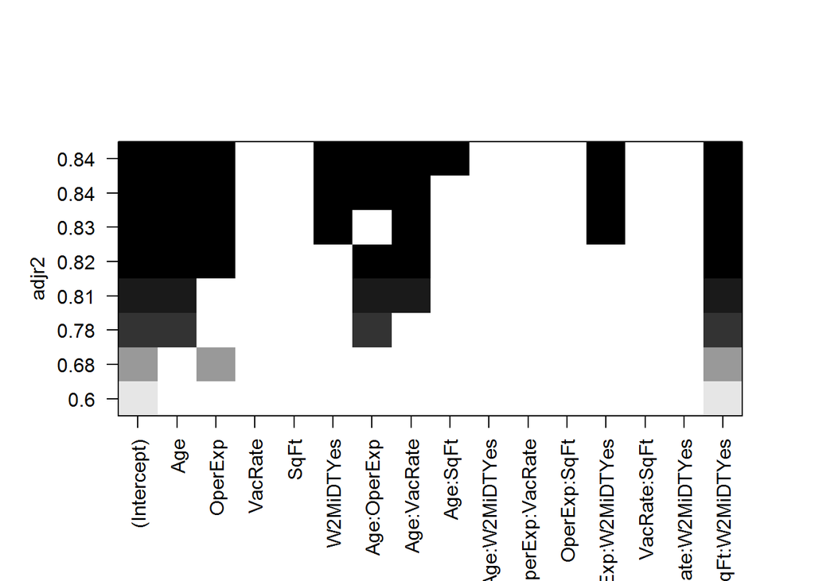

```r
subsets <-regsubsets(RentRate ~ Age + OperExp + VacRate + SqFt + W2MiDT + Age:OperExp +
                       Age:VacRate + Age:SqFt + Age:W2MiDT + OperExp:VacRate + OperExp:SqFt +
                       OperExp:W2MiDT + VacRate:SqFt + VacRate:W2MiDT + SqFt:W2MiDT, data=comm_prop)
plot(subsets, scale = 'adjr2' )
```

## Restrict values manually

To reduce over fitting and increase our F-statistic, we used stepwise regression and manually removed variables one at a time until all remaining variables had significant p-values.

```r
model_1 <- lm(RentRate ~ Age + OperExp + VacRate + SqFt + W2MiDT + Age:OperExp + Age:VacRate + Age:SqFt + Age:W2MiDT + OperExp:VacRate + OperExp:SqFt + OperExp:W2MiDT + VacRate:SqFt + SqFt:W2MiDT, data=comm_prop)
summary(model_1)
```

```
##
## Call:
## lm(formula = RentRate ~ Age + OperExp + VacRate + SqFt + W2MiDT +
##     Age:OperExp + Age:VacRate + Age:SqFt + Age:W2MiDT + OperExp:VacRate +
##     OperExp:SqFt + OperExp:W2MiDT + VacRate:SqFt + SqFt:W2MiDT,
##     data = comm_prop)
##
## Residuals:
##      Min       1Q   Median       3Q      Max
## -1.90654 -0.39779 -0.01684  0.39889  2.01306
##
## Coefficients:
##                     Estimate Std. Error t value Pr(>|t|)
## (Intercept)        1.249e+01  6.818e-01  18.320  < 2e-16 ***
## Age               -2.051e-01  5.782e-02  -3.547 0.000638 ***
## OperExp            2.893e-01  7.878e-02   3.673 0.000419 ***
## VacRate           -6.089e+00  3.385e+00  -1.799 0.075621 .
## SqFt               3.845e-06  5.559e-06   0.692 0.490965
## W2MiDTYes          1.438e+00  9.568e-01   1.503 0.136489
## Age:OperExp        1.158e-02  6.560e-03   1.766 0.080983 .
## Age:VacRate       -5.159e-01  1.622e-01  -3.181 0.002048 **
## Age:SqFt           2.542e-07  1.868e-07   1.361 0.177198
## Age:W2MiDTYes     -5.254e-02  4.015e-02  -1.309 0.194175
## OperExp:VacRate    6.052e-01  3.852e-01   1.571 0.119878
## OperExp:SqFt      -5.634e-07  4.912e-07  -1.147 0.254610
## OperExp:W2MiDTYes -1.750e-01  9.400e-02  -1.862 0.066041 .
## VacRate:SqFt       1.093e-05  1.051e-05   1.040 0.301063
## SqFt:W2MiDTYes     1.161e-05  1.895e-06   6.125 2.72e-08 ***
## ---
## Signif. codes:  0 '***' 0.001 '**' 0.01 '*' 0.05 '.' 0.1 ' ' 1
##
## Residual standard error: 0.7497 on 85 degrees of freedom
## Multiple R-squared:  0.8666, Adjusted R-squared:  0.8446
## F-statistic: 39.45 on 14 and 85 DF,  p-value: < 2.2e-16
```

```r
#remove VacRate:SqFt
model_2 <- lm(RentRate ~ Age + OperExp + VacRate + SqFt + W2MiDT + Age:OperExp + Age:VacRate + Age:SqFt + Age:W2MiDT + OperExp:VacRate + OperExp:SqFt + OperExp:W2MiDT + SqFt:W2MiDT, data=comm_prop)
summary(model_2)
```

```
##
## Call:
## lm(formula = RentRate ~ Age + OperExp + VacRate + SqFt + W2MiDT +
##     Age:OperExp + Age:VacRate + Age:SqFt + Age:W2MiDT + OperExp:VacRate +
##     OperExp:SqFt + OperExp:W2MiDT + SqFt:W2MiDT, data = comm_prop)
##
## Residuals:
##      Min       1Q   Median       3Q      Max
## -1.90523 -0.42036  0.01352  0.40044  2.04155
##
## Coefficients:
##                     Estimate Std. Error t value Pr(>|t|)
## (Intercept)        1.234e+01  6.663e-01  18.518  < 2e-16 ***
## Age               -2.030e-01  5.781e-02  -3.511 0.000714 ***
## OperExp            2.907e-01  7.880e-02   3.689 0.000394 ***
## VacRate           -3.835e+00  2.603e+00  -1.473 0.144272
## SqFt               4.814e-06  5.483e-06   0.878 0.382403
## W2MiDTYes          1.552e+00  9.510e-01   1.632 0.106393
## Age:OperExp        1.203e-02  6.549e-03   1.837 0.069600 .
## Age:VacRate       -5.594e-01  1.568e-01  -3.568 0.000591 ***
## Age:SqFt           2.090e-07  1.818e-07   1.150 0.253450
## Age:W2MiDTYes     -4.982e-02  4.008e-02  -1.243 0.217314
## OperExp:VacRate    5.821e-01  3.847e-01   1.513 0.133919
## OperExp:SqFt      -5.583e-07  4.914e-07  -1.136 0.259040
## OperExp:W2MiDTYes -1.885e-01  9.315e-02  -2.024 0.046097 *
## SqFt:W2MiDTYes     1.154e-05  1.895e-06   6.090 3.07e-08 ***
## ---
## Signif. codes:  0 '***' 0.001 '**' 0.01 '*' 0.05 '.' 0.1 ' ' 1
##
## Residual standard error: 0.7501 on 86 degrees of freedom
## Multiple R-squared:  0.8649, Adjusted R-squared:  0.8445
## F-statistic: 42.36 on 13 and 86 DF,  p-value: < 2.2e-16
```

```r
#remove OpenExp:SqFt
model_3 <- lm(RentRate ~ Age + OperExp + VacRate + SqFt + W2MiDT + Age:OperExp + Age:VacRate + Age:SqFt + Age:W2MiDT + OperExp:VacRate + OperExp:W2MiDT + SqFt:W2MiDT, data=comm_prop)
summary(model_3)
```

```
##
## Call:
## lm(formula = RentRate ~ Age + OperExp + VacRate + SqFt + W2MiDT +
##     Age:OperExp + Age:VacRate + Age:SqFt + Age:W2MiDT + OperExp:VacRate +
##     OperExp:W2MiDT + SqFt:W2MiDT, data = comm_prop)
##
## Residuals:
##      Min       1Q   Median       3Q      Max
## -1.88566 -0.46684  0.00596  0.41220  2.06144
##
## Coefficients:
##                     Estimate Std. Error t value Pr(>|t|)
## (Intercept)        1.272e+01  5.784e-01  21.987  < 2e-16 ***
## Age               -1.944e-01  5.742e-02  -3.386 0.001065 **
## OperExp            2.513e-01  7.089e-02   3.546 0.000633 ***
## VacRate           -3.253e+00  2.556e+00  -1.273 0.206549
## SqFt              -8.517e-07  2.283e-06  -0.373 0.710047
## W2MiDTYes          2.149e+00  7.941e-01   2.706 0.008193 **
## Age:OperExp        1.127e-02  6.525e-03   1.727 0.087691 .
## Age:VacRate       -5.589e-01  1.570e-01  -3.559 0.000606 ***
## Age:SqFt           1.840e-07  1.808e-07   1.018 0.311448
## Age:W2MiDTYes     -5.304e-02  4.005e-02  -1.324 0.188843
## OperExp:VacRate    5.342e-01  3.831e-01   1.395 0.166697
## OperExp:W2MiDTYes -2.400e-01  8.153e-02  -2.943 0.004163 **
## SqFt:W2MiDTYes     1.122e-05  1.877e-06   5.978 4.86e-08 ***
## ---
## Signif. codes:  0 '***' 0.001 '**' 0.01 '*' 0.05 '.' 0.1 ' ' 1
##
## Residual standard error: 0.7513 on 87 degrees of freedom
## Multiple R-squared:  0.8629, Adjusted R-squared:  0.844
## F-statistic: 45.62 on 12 and 87 DF,  p-value: < 2.2e-16
```

```r
#remove Age:SqFt
model_4 <- lm(RentRate ~ Age + OperExp + VacRate + SqFt + W2MiDT + Age:OperExp + Age:VacRate + Age:W2MiDT + OperExp:VacRate + OperExp:W2MiDT + SqFt:W2MiDT, data=comm_prop)
summary(model_4)
```

```
##
## Call:
## lm(formula = RentRate ~ Age + OperExp + VacRate + SqFt + W2MiDT +
##     Age:OperExp + Age:VacRate + Age:W2MiDT + OperExp:VacRate +
##     OperExp:W2MiDT + SqFt:W2MiDT, data = comm_prop)
##
## Residuals:
##      Min       1Q   Median       3Q      Max
## -1.93865 -0.43795  0.01214  0.41484  2.01947
##
## Coefficients:
##                     Estimate Std. Error t value Pr(>|t|)
## (Intercept)        1.272e+01  5.785e-01  21.993  < 2e-16 ***
## Age               -1.995e-01  5.722e-02  -3.487 0.000766 ***
## OperExp            2.302e-01  6.778e-02   3.396 0.001029 **
## VacRate           -3.506e+00  2.544e+00  -1.378 0.171722
## SqFt               1.160e-06  1.144e-06   1.014 0.313203
## W2MiDTYes          1.952e+00  7.704e-01   2.534 0.013042 *
## Age:OperExp        1.402e-02  5.941e-03   2.360 0.020479 *
## Age:VacRate       -5.581e-01  1.571e-01  -3.553 0.000614 ***
## Age:W2MiDTYes     -3.528e-02  3.606e-02  -0.978 0.330586
## OperExp:VacRate    5.492e-01  3.828e-01   1.435 0.154969
## OperExp:W2MiDTYes -2.284e-01  8.075e-02  -2.828 0.005793 **
## SqFt:W2MiDTYes     1.076e-05  1.821e-06   5.906 6.46e-08 ***
## ---
## Signif. codes:  0 '***' 0.001 '**' 0.01 '*' 0.05 '.' 0.1 ' ' 1
##
## Residual standard error: 0.7515 on 88 degrees of freedom
## Multiple R-squared:  0.8613, Adjusted R-squared:  0.8439
## F-statistic: 49.66 on 11 and 88 DF,  p-value: < 2.2e-16
```

```r
#remove Age:W2MiDT
model_5 <- lm(RentRate ~ Age + OperExp + VacRate + SqFt + W2MiDT + Age:OperExp + Age:VacRate + OperExp:VacRate + OperExp:W2MiDT + SqFt:W2MiDT, data=comm_prop)
summary(model_5)
```

```
##
## Call:
## lm(formula = RentRate ~ Age + OperExp + VacRate + SqFt + W2MiDT +
##     Age:OperExp + Age:VacRate + OperExp:VacRate + OperExp:W2MiDT +
##     SqFt:W2MiDT, data = comm_prop)
##
## Residuals:
##      Min       1Q   Median       3Q      Max
## -2.15107 -0.41888  0.02373  0.41204  2.07305
##
## Coefficients:
##                     Estimate Std. Error t value Pr(>|t|)
## (Intercept)        1.257e+01  5.564e-01  22.588  < 2e-16 ***
## Age               -1.897e-01  5.631e-02  -3.368 0.001120 **
## OperExp            2.534e-01  6.347e-02   3.992 0.000134 ***
## VacRate           -3.230e+00  2.528e+00  -1.278 0.204665
## SqFt               1.376e-06  1.122e-06   1.226 0.223351
## W2MiDTYes          2.118e+00  7.514e-01   2.819 0.005935 **
## Age:OperExp        1.197e-02  5.558e-03   2.154 0.033942 *
## Age:VacRate       -5.426e-01  1.562e-01  -3.473 0.000796 ***
## OperExp:VacRate    5.173e-01  3.814e-01   1.356 0.178389
## OperExp:W2MiDTYes -2.542e-01  7.632e-02  -3.331 0.001263 **
## SqFt:W2MiDTYes     1.007e-05  1.679e-06   5.997 4.24e-08 ***
## ---
## Signif. codes:  0 '***' 0.001 '**' 0.01 '*' 0.05 '.' 0.1 ' ' 1
##
## Residual standard error: 0.7513 on 89 degrees of freedom
## Multiple R-squared:  0.8597, Adjusted R-squared:  0.844
## F-statistic: 54.55 on 10 and 89 DF,  p-value: < 2.2e-16
```

```r
#remove OpenExp:VacRate
model_6 <- lm(RentRate ~ Age + OperExp + VacRate + SqFt + W2MiDT + Age:OperExp + Age:VacRate + OperExp:W2MiDT + SqFt:W2MiDT, data=comm_prop)
summary(model_6)
```

```
##
## Call:
## lm(formula = RentRate ~ Age + OperExp + VacRate + SqFt + W2MiDT +
##     Age:OperExp + Age:VacRate + OperExp:W2MiDT + SqFt:W2MiDT,
##     data = comm_prop)
##
## Residuals:
##      Min       1Q   Median       3Q      Max
## -2.13444 -0.36142 -0.02939  0.39724  2.10233
##
## Coefficients:
##                     Estimate Std. Error t value Pr(>|t|)
## (Intercept)        1.244e+01  5.513e-01  22.571  < 2e-16 ***
## Age               -1.971e-01  5.631e-02  -3.500 0.000725 ***
## OperExp            2.723e-01  6.221e-02   4.376 3.24e-05 ***
## VacRate           -5.036e-02  9.508e-01  -0.053 0.957878
## SqFt               1.458e-06  1.126e-06   1.295 0.198545
## W2MiDTYes          2.050e+00  7.532e-01   2.722 0.007801 **
## Age:OperExp        1.232e-02  5.578e-03   2.209 0.029694 *
## Age:VacRate       -4.408e-01  1.377e-01  -3.202 0.001886 **
## OperExp:W2MiDTYes -2.423e-01  7.616e-02  -3.181 0.002014 **
## SqFt:W2MiDTYes     9.731e-06  1.668e-06   5.834 8.41e-08 ***
## ---
## Signif. codes:  0 '***' 0.001 '**' 0.01 '*' 0.05 '.' 0.1 ' ' 1
##
## Residual standard error: 0.7548 on 90 degrees of freedom
## Multiple R-squared:  0.8568, Adjusted R-squared:  0.8425
## F-statistic: 59.85 on 9 and 90 DF,  p-value: < 2.2e-16
```

```r
#remove Age:OpenExp
model_7 <- lm(RentRate ~ Age + OperExp + VacRate + SqFt + W2MiDT + Age:VacRate + OperExp:W2MiDT + SqFt:W2MiDT, data=comm_prop)
summary(model_7)
```

```
##
## Call:
## lm(formula = RentRate ~ Age + OperExp + VacRate + SqFt + W2MiDT +
##     Age:VacRate + OperExp:W2MiDT + SqFt:W2MiDT, data = comm_prop)
##
## Residuals:
##      Min       1Q   Median       3Q      Max
## -2.17204 -0.41795 -0.05323  0.42290  1.92413
##
## Coefficients:
##                     Estimate Std. Error t value Pr(>|t|)
## (Intercept)        1.156e+01  3.859e-01  29.950  < 2e-16 ***
## Age               -7.815e-02  1.686e-02  -4.636 1.18e-05 ***
## OperExp            3.671e-01  4.598e-02   7.985 4.12e-12 ***
## VacRate            3.215e-01  9.555e-01   0.336 0.737299
## SqFt               1.864e-06  1.134e-06   1.643 0.103742
## W2MiDTYes          2.178e+00  7.668e-01   2.840 0.005563 **
## Age:VacRate       -5.106e-01  1.368e-01  -3.732 0.000331 ***
## OperExp:W2MiDTYes -2.765e-01  7.615e-02  -3.631 0.000466 ***
## SqFt:W2MiDTYes     1.036e-05  1.678e-06   6.173 1.84e-08 ***
## ---
## Signif. codes:  0 '***' 0.001 '**' 0.01 '*' 0.05 '.' 0.1 ' ' 1
##
## Residual standard error: 0.7707 on 91 degrees of freedom
## Multiple R-squared:  0.8491, Adjusted R-squared:  0.8358
## F-statistic: 63.99 on 8 and 91 DF,  p-value: < 2.2e-16
```

```r
new_RentRate <- data.frame(Age=9, OperExp=13, VacRate=0, SqFt=40, Taxes=540, W2MiDT='No')
ori_pred <- predict(model.full.int, newdata=new_RentRate, interval="predict")
predict(model_7, newdata=new_RentRate, interval="predict")
```

```
##       fit      lwr      upr
## 1 15.6259 13.98476 17.26704
```

## Run backward stepwise regression

We also ran the backward stepwise regression function and examined the results to compare them to our manual version. Interestingly, it came up with slightly different variables. The first noticeable change is that the function kept Taxes instead of SqFt. Additionally, it kept Age:OperExp and OperExp:VacRate where our manual model recommended removing them.

Manual variables: Age, OperExp, VacRate, SqFt, W2MiDT, Age:VacRate, OperExp:W2MiDT, SqFt:W2MiDT

stepAIC variables: Age, OperExp, VacRate, Taxes, W2MiDT, Age:OperExp, Age:VacRate, OperExp:VacRate, OperExp:W2MiDT, Taxes:W2MiDT

The result was that the model created by the function had a slightly better adjusted R^2 of 0.844 compared to 0.8358, but a significantly worse F-statistic of 54.55 compared to 63.99. As such, we moved forward with our analysis using the model created using the manual method.

```r
model_step <- lm(RentRate ~ .*., data = comm_prop)
stepAIC(model_step, direction = "backward")
```

```
## Start:  AIC=-31.72
## RentRate ~ (Age + OperExp + VacRate + SqFt + Taxes + W2MiDT) *
##     (Age + OperExp + VacRate + SqFt + Taxes + W2MiDT)
##
##                   Df Sum of Sq    RSS     AIC
## - SqFt:W2MiDT      1    0.0006 46.897 -33.722
## - Taxes:W2MiDT     1    0.0009 46.897 -33.722
## - VacRate:W2MiDT   1    0.0038 46.900 -33.716
## - SqFt:Taxes       1    0.1146 47.011 -33.480
## - OperExp:SqFt     1    0.1263 47.022 -33.455
## - OperExp:Taxes    1    0.1271 47.023 -33.453
## - VacRate:Taxes    1    0.1799 47.076 -33.341
## - VacRate:SqFt     1    0.1809 47.077 -33.339
## - Age:SqFt         1    0.5911 47.487 -32.471
## - Age:Taxes        1    0.5942 47.490 -32.464
## <none>                         46.896 -31.724
## - Age:W2MiDT       1    1.0418 47.938 -31.526
## - Age:OperExp      1    1.0439 47.940 -31.522
## - OperExp:W2MiDT   1    1.5674 48.463 -30.436
## - OperExp:VacRate  1    1.6506 48.547 -30.264
## - Age:VacRate      1    3.7819 50.678 -25.968
##
## Step:  AIC=-33.72
## RentRate ~ Age + OperExp + VacRate + SqFt + Taxes + W2MiDT +
##     Age:OperExp + Age:VacRate + Age:SqFt + Age:Taxes + Age:W2MiDT +
##     OperExp:VacRate + OperExp:SqFt + OperExp:Taxes + OperExp:W2MiDT +
##     VacRate:SqFt + VacRate:Taxes + VacRate:W2MiDT + SqFt:Taxes +
##     Taxes:W2MiDT
##
##                   Df Sum of Sq    RSS     AIC
## - VacRate:W2MiDT   1    0.0041 46.901 -35.714
## - SqFt:Taxes       1    0.1214 47.018 -35.464
## - OperExp:SqFt     1    0.1489 47.046 -35.405
## - OperExp:Taxes    1    0.1499 47.047 -35.403
## - VacRate:Taxes    1    0.1808 47.078 -35.337
## - VacRate:SqFt     1    0.1819 47.079 -35.335
## - Age:SqFt         1    0.6761 47.573 -34.291
## - Age:Taxes        1    0.6795 47.576 -34.284
## <none>                         46.897 -33.722
## - Age:W2MiDT       1    1.0510 47.948 -33.506
```

[output cut: 163 more lines]

```
## - OperExp:W2MiDT   1    4.5098 54.210 -39.231
## - Age:VacRate      1    7.1267 56.826 -34.517
## - Taxes:W2MiDT     1   19.6918 69.392 -14.541
##
## Step:  AIC=-46.83
## RentRate ~ Age + OperExp + VacRate + Taxes + W2MiDT + Age:OperExp +
##     Age:VacRate + OperExp:VacRate + OperExp:W2MiDT + Taxes:W2MiDT
##
##                   Df Sum of Sq    RSS     AIC
## <none>                         50.241 -46.833
## - OperExp:VacRate  1    1.0343 51.276 -46.795
## - Age:OperExp      1    2.6188 52.860 -43.752
## - OperExp:W2MiDT   1    6.2537 56.495 -37.102
## - Age:VacRate      1    6.8055 57.047 -36.130
## - Taxes:W2MiDT     1   20.2879 70.529 -14.914
```

```
##
## Call:
## lm(formula = RentRate ~ Age + OperExp + VacRate + Taxes + W2MiDT +
##     Age:OperExp + Age:VacRate + OperExp:VacRate + OperExp:W2MiDT +
##     Taxes:W2MiDT, data = comm_prop)
##
## Coefficients:
##       (Intercept)                Age            OperExp
##          12.56803           -0.18967            0.25345
##           VacRate              Taxes          W2MiDTYes
##          -3.22234            0.07645            2.11716
##       Age:OperExp        Age:VacRate    OperExp:VacRate
##           0.01197           -0.54248            0.51621
## OperExp:W2MiDTYes    Taxes:W2MiDTYes
##          -0.25400            0.55883
```

```r
step_lm <- lm(RentRate ~ Age + OperExp + VacRate + Taxes + W2MiDT + Age:OperExp + Age:VacRate + OperExp:VacRate + OperExp:W2MiDT + Taxes:W2MiDT, data = comm_prop)
summary(step_lm)
```

```
##
## Call:
## lm(formula = RentRate ~ Age + OperExp + VacRate + Taxes + W2MiDT +
##     Age:OperExp + Age:VacRate + OperExp:VacRate + OperExp:W2MiDT +
##     Taxes:W2MiDT, data = comm_prop)
##
## Residuals:
##      Min       1Q   Median       3Q      Max
## -2.15120 -0.41853  0.02372  0.41115  2.07336
##
## Coefficients:
##                    Estimate Std. Error t value Pr(>|t|)
## (Intercept)       12.568031   0.556461  22.586  < 2e-16 ***
## Age               -0.189674   0.056318  -3.368 0.001121 **
## OperExp            0.253455   0.063470   3.993 0.000134 ***
## VacRate           -3.222338   2.527990  -1.275 0.205746
## Taxes              0.076454   0.062327   1.227 0.223187
## W2MiDTYes          2.117163   0.751416   2.818 0.005961 **
## Age:OperExp        0.011972   0.005558   2.154 0.033956 *
## Age:VacRate       -0.542475   0.156238  -3.472 0.000799 ***
## OperExp:VacRate    0.516211   0.381367   1.354 0.179298
## OperExp:W2MiDTYes -0.253997   0.076312  -3.328 0.001272 **
## Taxes:W2MiDTYes    0.558834   0.093218   5.995 4.27e-08 ***
## ---
## Signif. codes:  0 '***' 0.001 '**' 0.01 '*' 0.05 '.' 0.1 ' ' 1
##
## Residual standard error: 0.7513 on 89 degrees of freedom
## Multiple R-squared:  0.8597, Adjusted R-squared:  0.844
## F-statistic: 54.55 on 10 and 89 DF,  p-value: < 2.2e-16
```

## Model Analysis

The models showed generally decreasing p-values, but these reductions were marginal. The reduction was more than made up for by the increases in the F-statistic - a difference of 24.54. The updated model has also given us a tighter range. It decreases our initial range of $4,074.80 down to an updated range of $3,282.28. A difference of nearly $800.

An analysis of the residuals showed that there is still no discernible pattern and even shows slightly less clumping than the model created from just single variables. The analysis of variance on both the single variable and manual stepwise models shows good significance. The significance for the OperExp:W2MiDT variable appears to fall outside the range of significance although it was within bounds when running the analysis on the coefficients. The fitted plot shows tighter grouping around the line, but still quite a bit of variance from the prediction.

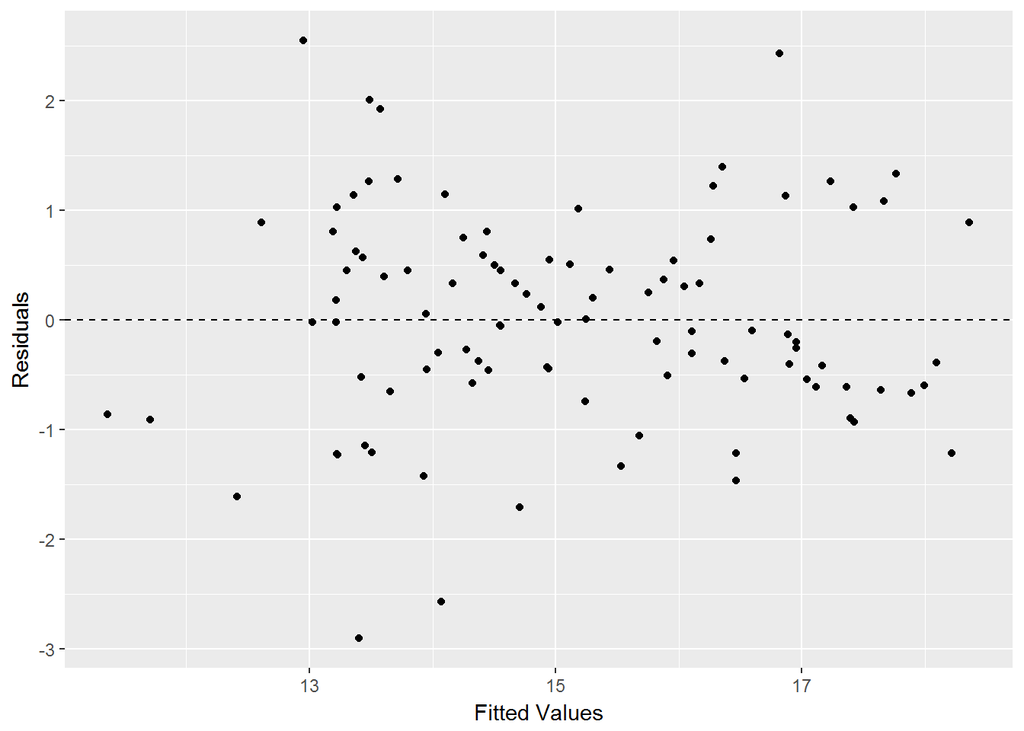

```r
full.df <- fortify(df_model)
ggplot(full.df, aes(x=.fitted, y=.resid)) +
  geom_point() +
  geom_hline(yintercept=0, linetype=2) +
  labs(x="Fitted Values", y="Residuals")
```

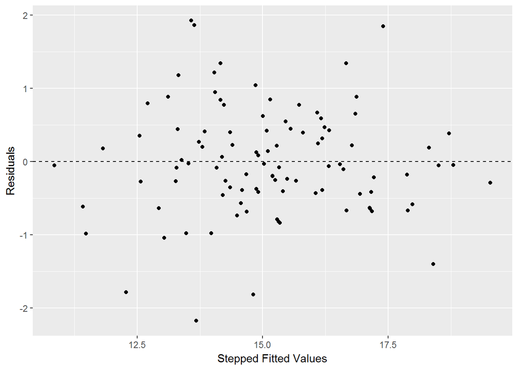

```r
step.df <- fortify(model_7)
ggplot(step.df, aes(x=.fitted, y=.resid)) +
  geom_point() +
  geom_hline(yintercept=0, linetype=2) +
  labs(x="Stepped Fitted Values", y="Residuals")
```

```r
shapiro.test(df_model$residuals)
```

```
##
##  Shapiro-Wilk normality test
##
## data:  df_model$residuals
## W = 0.98932, p-value = 0.6099
```

```r
ncvTest(df_model)
```

```
## Non-constant Variance Score Test
## Variance formula: ~ fitted.values
## Chisquare = 3.279042    Df = 1     p = 0.07016989
```

```r
vif(df_model)
```

```
##      Age  OperExp   W2MiDT     SqFt
## 1.459694 1.366874 1.527237 1.582381
```

```r
shapiro.test(model_7$residuals)
```

```
##
##  Shapiro-Wilk normality test
##
## data:  model_7$residuals
## W = 0.98303, p-value = 0.2272
```

```r
ncvTest(model_7)
```

```
## Non-constant Variance Score Test
## Variance formula: ~ fitted.values
## Chisquare = 3.131436    Df = 1     p = 0.07679607
```

```r
vif(model_7)
```

```
##            Age        OperExp        VacRate           SqFt         W2MiDT
##       1.998462       2.436396       2.355302       2.695679      22.804759
##    Age:VacRate OperExp:W2MiDT    SqFt:W2MiDT
##       2.021693      27.054264       7.277338
```

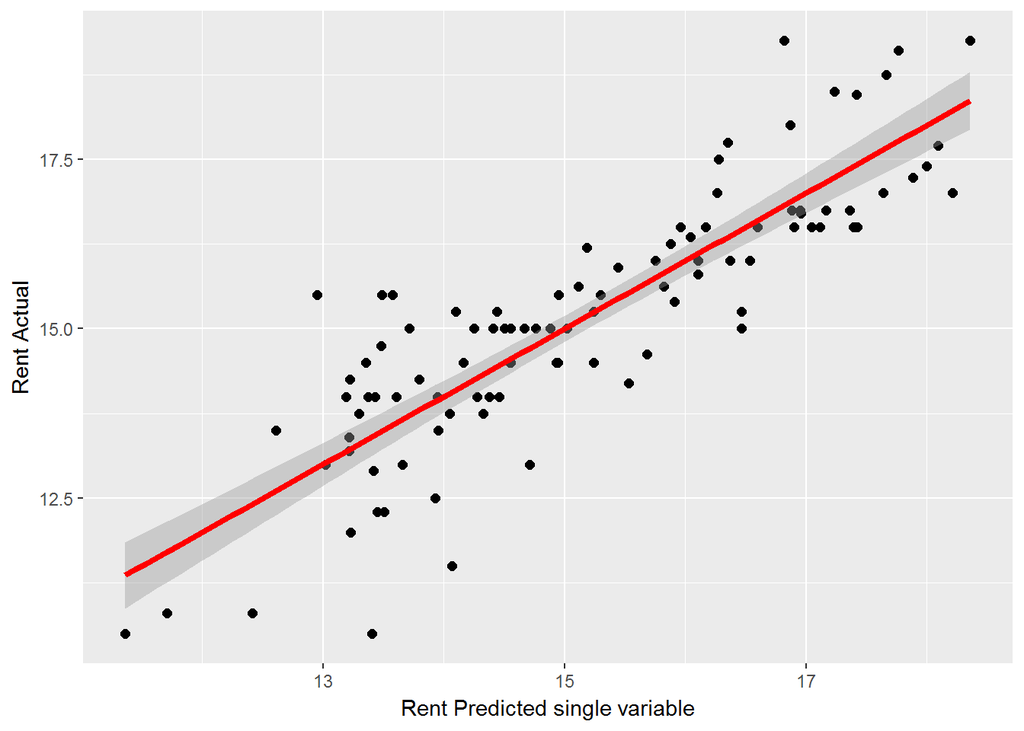

```r
ggplot(full.df, aes(x=.fitted, y=RentRate)) +
  geom_point(size=2) +
  geom_smooth(method="lm", color="red", lwd=1.5) +
  labs(x="Rent Predicted single variable", y="Rent Actual")
```

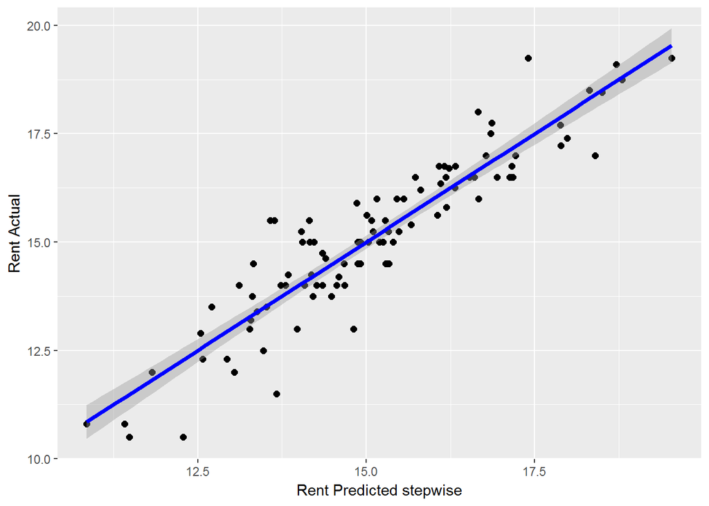

```r
ggplot(step.df, aes(x=.fitted, y=RentRate)) +
  geom_point(size=2) +
  geom_smooth(method="lm", color="blue", lwd=1.5) +
  labs(x="Rent Predicted stepwise", y="Rent Actual")
```

```r
single_variables <- aov(RentRate ~ Age + OperExp + W2MiDT + SqFt, data = comm_prop)
stepwise_variables <- aov(RentRate ~ Age + OperExp + VacRate + SqFt + W2MiDT + Age:VacRate + OperExp:W2MiDT + SqFt:W2MiDT, data = comm_prop)

summary(single_variables)
```

```
##             Df Sum Sq Mean Sq F value   Pr(>F)
## Age          1  26.46   26.46   27.21 1.07e-06 ***
## OperExp      1 127.42  127.42  131.06  < 2e-16 ***
## W2MiDT       1  77.21   77.21   79.41 3.50e-14 ***
## SqFt         1  34.72   34.72   35.71 3.98e-08 ***
## Residuals   95  92.37    0.97
## ---
## Signif. codes:  0 '***' 0.001 '**' 0.01 '*' 0.05 '.' 0.1 ' ' 1
```

```r
summary(stepwise_variables)
```

```
##                Df Sum Sq Mean Sq F value   Pr(>F)
## Age             1  26.46   26.46  44.538 1.91e-09 ***
## OperExp         1 127.42  127.42 214.508  < 2e-16 ***
## VacRate         1   4.78    4.78   8.046  0.00562 **
## SqFt            1  76.11   76.11 128.128  < 2e-16 ***
## W2MiDT          1  31.93   31.93  53.758 9.04e-11 ***
## Age:VacRate     1  13.48   13.48  22.690 7.16e-06 ***
## OperExp:W2MiDT  1   1.30    1.30   2.191  0.14230
## SqFt:W2MiDT     1  22.63   22.63  38.102 1.84e-08 ***
## Residuals      91  54.06    0.59
## ---
## Signif. codes:  0 '***' 0.001 '**' 0.01 '*' 0.05 '.' 0.1 ' ' 1
```

# What to Charge

Lastly we used our model to determine a range for what we can charge in rent for our building. For this we used the model created by the manual stepwise regression. The model indicates we could charge between $13,984.76 and $17,267.04 per month to rent out the building. Taking into account that our break even point to run the building is $13,540, our model indicates we should rent the space. There may be additional expenses we should factor in, such as maintenance expenses for upkeep and repair. However, based on the current information and operating expenses, we could easily rent the building for over $13,540.

```r
new_RentRate <- data.frame(Age=9, OperExp=13, VacRate=0, SqFt=40, Taxes=540, W2MiDT='No')
predict(model_7, newdata=new_RentRate, interval="predict")
```

```
##       fit      lwr      upr
## 1 15.6259 13.98476 17.26704
```

# Final Conclusion

Our final model explains around 83% of the variability in the data we collected on the 100 properties. This should give us a good enough idea on what to charge in rent to make it profitable to rent instead of sell. However, there may be other variables we need to take into account in order to establish a better range. One variable that comes to mind is the neighborhood. For example, the desirability of a building in the Gulch is different than in Germantown. The facilities available in the building could also effect the amount charged for rent. For example, whether or not the building can be used as a restaurant, store, or solely as office space.

In being a statistical model, it would probably need to be explained to a business audience. But the included graphics should serve to illustrate the point and end conclusion.